# 第 5 章 惩罚回归与最小方差组合的稀疏对冲

本章介绍线性模型中广泛使用的正则化方法。这类模型有多种应用。第一种很直接：在基于因子的预测回归中加入惩罚项，以提高估计的稳健性，再将预测结果用于资产配置。例如，Han 等人 (2019) 以及 Rapach 和 Zhou (2019) 使用惩罚回归来组合由不同公司特征产生的预测，从而改进股票收益率预测。

类似思路也可以用于宏观经济预测，例如 Uematsu 和 Tanaka (2019)。第二种应用源自 Stevens (1998) 一个较少为人所知的结果：最优均值—方差投资组合的权重，可以与一类特定的横截面回归联系起来。此时，正则化的目的不再是直接改善收益率预测，而是提高均值—方差投资组合权重的估计质量。下面先介绍线性模型的正则化技术，再讨论这两类应用。

惩罚方法在金融中的其他应用，还可见 d’Aspremont (2011)、Ban、El Karoui 和 Lim (2016) 以及 Kremer 等人 (2019)。这些应用都遵循 Tibshirani (1996) 开创性论文中的基本思想：标准的无约束优化可能产生噪声较大的估计；加入结构性约束，可以牺牲一定偏差来降低噪声。例如，Kremer 等人 (2019) 借此构建更稳健的均值—方差投资组合（Markowitz (1952)），Freyberger、Neuhierl 和 Weber (2020) 则用它筛选真正有助于解释股票收益率横截面差异的特征。

## 5.1 惩罚回归

### 5.1.1 简单回归

线性模型已有至少两个世纪的历史，Legendre (1805) 是最早讨论最小二乘优化的文献之一。给定预测变量矩阵 $\textbf{X}$，我们把输出向量 $\textbf{y}$ 分解为 $\textbf{X}$ 各列的线性组合（记为 $\textbf{X}\boldsymbol{\beta}$）与误差项 $\boldsymbol{\epsilon}$ 之和：$\textbf{y}=\textbf{X}\boldsymbol{\beta}+\boldsymbol{\epsilon}$。

最优的 $\boldsymbol{\beta}$ 自然应使误差尽可能小。为便于解析求解，我们最小化误差平方和：$L=\boldsymbol{\epsilon}'\boldsymbol{\epsilon}=\sum_{i=1}^I\epsilon_i^2$。损失函数 $L$ 称为残差平方和（SSR）。求解最优 $\boldsymbol{\beta}$ 时，需要对 $L$ 关于 $\boldsymbol{\beta}$ 求导；一阶条件要求梯度等于 0：

\begin{align*} \nabla_{\boldsymbol{\beta}} L&=\frac{\partial}{\partial \boldsymbol{\beta}}(\textbf{y}-\textbf{X}\boldsymbol{\beta})'(\textbf{y}-\textbf{X}\boldsymbol{\beta})=\frac{\partial}{\partial \boldsymbol{\beta}}\boldsymbol{\beta}'\textbf{X}'\textbf{X}\boldsymbol{\beta}-2\textbf{y}'\textbf{X}\boldsymbol{\beta} \\ &=2\textbf{X}'\textbf{X}\boldsymbol{\beta} -2\textbf{X}'\textbf{y} \end{align*}

因此，当下式成立时，一阶条件 $\nabla_{\boldsymbol{\beta}}=\textbf{0}$ 得到满足：

\begin{equation} \tag{5.1} \boldsymbol{\beta}^*=(\textbf{X}'\textbf{X})^{-1}\textbf{X}'\textbf{y}, \end{equation}

这就是线性模型的标准普通最小二乘（OLS）解。若矩阵 $\textbf{X}$ 的维度为 $I \times K$，通常只有行数 $I$ 严格大于列数 $K$ 时，$\textbf{X}'\textbf{X}$ 才可逆。有些数据并不满足这一条件：预测变量多于样本，此时不存在唯一的 $\textbf{β}$ 使损失最小。若 $\textbf{X}'\textbf{X}$ 非奇异（或正定），二阶条件可以保证 $\textbf{β*}$ 是损失 $L$ 的全局最小点，因为 $L$ 关于 $\textbf{β}$ 的二阶导数，即 Hessian 矩阵，正是 $\textbf{X}'\textbf{X}$。

到目前为止，我们尚未对上述变量的分布作任何假设。常见假设包括：

- $\mathbb{E}[\textbf{y}|\textbf{X}]=\textbf{X}\boldsymbol{\beta}$：回归函数为**线性形式**；
- $\mathbb{E}[\boldsymbol{\epsilon}|\textbf{X}]=\textbf{0}$：给定预测变量时，误差项的**条件期望为零**；
- $\mathbb{E}[\boldsymbol{\epsilon}\boldsymbol{\epsilon}'| \textbf{X}]=\sigma^2\textbf{I}$：满足**同方差性**，即误差之间不相关且方差相同；
- $\epsilon_i$ 服从正态分布。

在这些假设下，可以对系数估计量 $\hat{\boldsymbol{\beta}}$ 进行统计检验。关于线性模型的系统介绍，参见 Greene (2018) 第 2 至第 4 章；相应统计检验的细节见该书第 5 章。

### 5.1.2 惩罚形式

Tibshirani (1996) 的开创性工作推动了惩罚回归的普及。其基本思想是约束回归系数，限制系数绝对值的总规模。在原始论文中，Tibshirani (1996) 提出了以下 LASSO 模型：

\begin{equation} \tag{5.2} y_i = \sum_{j=1}^J \beta_jx_{i,j} + \epsilon_i, \quad i =1,\dots,I, \quad \text{s.t.} \quad \sum_{j=1}^J |\beta_j| < \delta, \end{equation}

其中，$\delta$ 是一个严格为正的常数。在最小二乘准则下，这等价于求解以下拉格朗日形式：

\begin{equation} \tag{5.3} \underset{\mathbf{\beta}}{\min} \, \left\{ \sum_{i=1}^I\left(y_i - \sum_{j=1}^J \beta_jx_{i,j} \right)^2+\lambda \sum_{j=1}^J |\beta_j| \right\}, \end{equation}

其中，$\lambda>0$ 的取值取决于 $\delta$：$\delta$ 越小，$\lambda$ 越大，约束也越强。这一形式看起来与岭回归（$L^2$ 正则化）很相似；事实上，岭回归早于 LASSO：

\begin{equation} \tag{5.4} \underset{\mathbf{\beta}}{\min} \, \left\{ \sum_{i=1}^I\left(y_i - \sum_{j=1}^J\beta_jx_{i,j} \right)^2+\lambda \sum_{j=1}^J \beta_j^2 \right\}, \end{equation}

它等价于估计以下模型：

\begin{equation} \tag{5.5} y_i = \sum_{j=1}^J \beta_jx_{i,j} + \epsilon_i, \quad i =1,\dots,I, \quad \text{s.t.} \quad \sum_{j=1}^J \beta_j^2 < \delta, \end{equation}

不过，两者得到的结果大不相同，因此有必要分别讨论。随着惩罚强度 $\lambda$ 增大（或式 (5.5) 中的 $\delta$ 减小），岭回归的所有系数都会平缓地向零收缩。LASSO 的收缩则更为直接：部分系数会很快变为零。当 $\lambda$ 足够大时，LASSO 最终只保留一个非零系数；岭回归的所有系数则只会渐近趋近于零。关于岭回归在数据科学中的广泛应用，以及它与交叉验证、Dropout（随机失活）正则化等主题的联系，可参阅 Hastie (2020) 的综述。

为说明 LASSO 与岭回归的差异，考虑图 5.1 中只有 $K=2$ 个预测变量的情形。红点表示位于平面中央的最优无约束解 $\boldsymbol{\beta}^*$，但它不满足给定约束。浅灰色区域表示可行域：LASSO 的约束 $|\beta_1|+|\beta_2| \le \delta$ 形成菱形，岭回归的约束 $\beta_1^2+\beta_2^2 \le \delta$ 形成圆形。为了满足约束，优化过程必须离开 $\boldsymbol{\beta}^*$，接受更大的误差。图中的橙色椭圆表示不同的等损失线；当某条等损失线首次接触灰色可行域边界时，接触点就是约束下的最优解。

[figure not shown]

图 5.1：LASSO 回归（左）与岭回归（右）示意图。

当外生变量多于观测值、经典回归没有唯一解时，这两种方法仍然适用。以岭回归为例，其解为

$\hat{\boldsymbol{\beta}}=(\mathbf{X}'\mathbf{X}+\lambda \mathbf{I}_N)^{-1}\mathbf{X}'\mathbf{Y}.$

与式 (5.1) 相比，新增的 $\lambda \mathbf{I}_N$ 保证只要 $\lambda>0$，逆矩阵就有定义。随着 $\lambda$ 增大，$\hat{\beta}_i$ 的绝对值逐渐减小。因此，惩罚方法也常被称为收缩方法，即估计系数会向零收缩。

Zou 和 Hastie (2005) 提出，可以用凸组合同时利用两种惩罚的优点，并将这种方法称为**弹性网**：

\begin{equation} \tag{5.6} y_i = \sum_{j=1}^J \beta_jx_{i,j} + \epsilon_i, \quad \text{s.t.} \quad \alpha \sum_{j=1}^J |\beta_j| +(1-\alpha)\sum_{j=1}^J \beta_j^2< \delta, \quad i =1,\dots,N, \end{equation}

对应的优化问题为

\begin{equation} \tag{5.7} \underset{\mathbf{\beta}}{\min} \, \left\{ \sum_{i=1}^I\left(y_i - \sum_{j=1}^J\beta_jx_{i,j} \right)^2+\lambda \left(\alpha\sum_{j=1}^J |\beta_j|+ (1-\alpha)\sum_{j=1}^J \beta_j^2\right) \right\}. \end{equation}

与岭回归相比，LASSO 的主要优势在于变量选择能力。面对大量预测变量时，LASSO 会逐步剔除相关性最低的变量。弹性网保留了这种选择能力；Zou 和 Hastie (2005) 指出，在某些情况下，它甚至比 LASSO 更有效。参数 $\alpha \in [0,1]$ 控制系数向零收缩的平滑程度：$\alpha$ 越接近零，收缩过程越平缓。

### 5.1.3 示例

```python
from sklearn.linear_model import Lasso, Ridge, ElasticNet
y_penalized = data_ml['R1M_Usd'].values # Dependent variable
X_penalized = data_ml[features].values # Predictors
alphas = np.arange(1e-4,1.0e-3,1e-5) # here alpha is used for lambda in scikit-learn
lasso_res = {} # declaring the dict that will receive the model's result
```

系数计算完成后，还需先整理数据才能绘图。由于系数数量较多，图中只展示其中一部分。

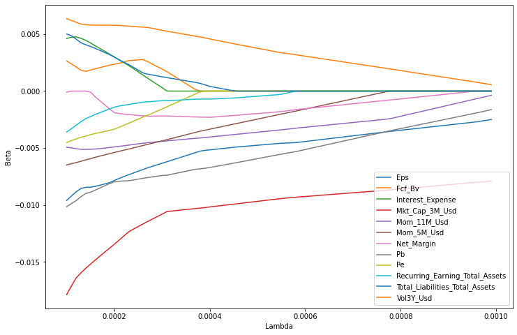

```python
for alpha in alphas: # looping through the different alphas/lambdas values
  lasso = Lasso(alpha=alpha) # model
  lasso.fit(X_penalized,y_penalized)
  lasso_res[alpha] = lasso.coef_ # extract LASSO coefs

df_lasso_res = pd.DataFrame.from_dict(lasso_res).T # transpose the dataframe for plotting
df_lasso_res.columns = features # adding the names of the factors
predictors = (df_lasso_res.abs().sum() > 0.05) # selecting the most relevant
df_lasso_res.loc[:,predictors].plot(xlabel='Lambda',ylabel='Beta',figsize=(12,8)); # Plot!
```

图 5.2：LASSO 模型，因变量为未来 1 个月收益率。

接下来考察岭回归。

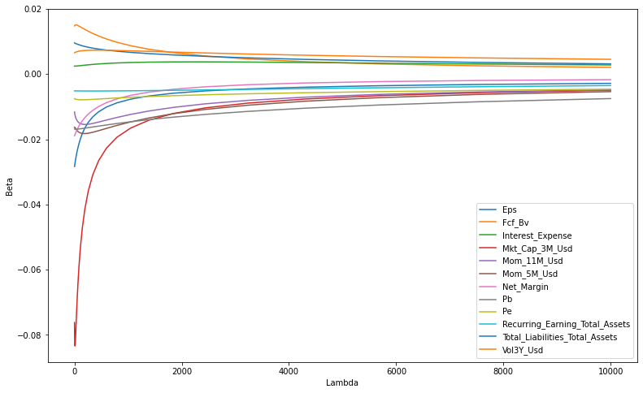

```python
n_alphas = 50 # declare the number of alphas for ridge
alphas = np.logspace(-2, 4, n_alphas) # transforming into log for Aspect ratio
ridge_res = {} # declaring the dict that will receive the model's result

for alpha in alphas: # looping through the different alphas/lambdas values
  ridge = Ridge(alpha=alpha) # model
  ridge.fit(X_penalized,y_penalized) # fit the model
  ridge_res[alpha] = ridge.coef_ # extract RIDGE coefs

df_ridge_res = pd.DataFrame.from_dict(ridge_res).T # transpose the dataframe for plotting
df_ridge_res.columns = features # adding the names of the factors
df_ridge_res.loc[:,predictors].plot(xlabel='Lambda',ylabel='Beta',figsize=(13,8)); # Plot!
```

图 5.3：岭回归，因变量为未来 1 个月收益率。

## 5.2 最小方差投资组合的稀疏对冲

### 5.2.1 方法与推导

构建稀疏投资组合的思想本身并不新颖（例如，参见 Brodie 等人 (2009) 以及 Fastrich、Paterlini 和 Winker (2015)）；在经典二次规划中，它与 LASSO 变量选择性质的联系也很直接。这里必须选用 $L^1$ 范数，因为简单施加 $L^2$ 范数反而会提高投资组合的分散程度（参见 Coqueret (2015)）。

本节的思路来自 Goto 和 Xu (2015)，但其基础性结论最早由 Stevens (1998) 提出。由于相关推导在文献中并不常见，下面给出详细过程。

在常见的均值—方差配置中，资产收益率的逆协方差矩阵 $\mathbf{\Sigma}^{-1}$ 是核心要素之一。例如，最大夏普比率（MSR）投资组合为

\begin{equation} \tag{5.8} \mathbf{w}^{\text{MSR}}=\frac{\mathbf{\Sigma}^{-1}\boldsymbol{\mu}}{\mathbf{1}'\mathbf{\Sigma}^{-1}\boldsymbol{\mu}}, \end{equation}

其中，$\mu$ 是预期超额收益率向量。令 $\mathbf{\mu}=\mathbf{1}$，即可得到最小方差投资组合。  
它不需要估计预期收益率这一阶矩，因此通常比那些尝试估计 $\mu$、却往往估计不准的方法更稳健。

传统做法是先估计 Σ，再对其求逆以得到 MSR 权重。不过，也有一些方法直接估计 $\boldsymbol{\Sigma}^{-1}$，下面介绍其中一种。我们每次处理一项资产，也就是逐行估计 $\boldsymbol{\Sigma}^{-1}$。先将矩阵 $\mathbf{\Sigma}$ 分块写为：

$\mathbf{\Sigma}= \left[\begin{array}{cc} \sigma^2 & \mathbf{c}' \\ \mathbf{c}& \mathbf{C}\end{array} \right],$

根据经典的分块矩阵结果，例如 Schur 补，可得

我们关注第一行，它包含两部分：标量因子 $(\sigma^2 -\mathbf{c}'\mathbf{C}^{-1}\mathbf{c})^{-1}$ 和行向量 $\mathbf{c}'\mathbf{C}^{-1}$。$\mathbf{C}$ 是资产 $2$ 至 $N$ 的协方差矩阵，$c$ 则表示资产 1 与其他各项资产的协方差。因此，$\mathbf{\Sigma}^{-1}$ 的第一行为

\begin{equation} \tag{5.9} (\sigma^2 -\mathbf{c}'\mathbf{C}^{-1}\mathbf{c})^{-1} \left[1 \quad \underbrace{-\mathbf{c}'\mathbf{C}^{-1}}_{N-1 \text{ terms}} \right]. \end{equation}

下面换一个角度：用其他所有资产的收益率解释资产 1 的收益率，建立回归

\begin{equation} \tag{5.10} r_{1,t}=a_1+\sum_{n=2}^N\beta_{1|n}r_{n,t}+\epsilon_t, \quad \text{ i.e., } \quad \mathbf{r}_1=a_1\mathbf{1}_T+\mathbf{R}_{-1}\mathbf{\beta}_1+\epsilon_1, \end{equation}

其中，$\mathbf{R}_{-1}$ 汇集了除资产 1 之外所有资产的收益率。$\mathbf{\beta}_1$ 的 OLS 估计量为

\begin{equation} \tag{5.11} \hat{\mathbf{\beta}}_{1}=\mathbf{C}^{-1}\mathbf{c}, \end{equation}

这是包含常数项时由 Frisch-Waugh-Lovell 定理得到的分块形式（参见 Greene (2018) 第 3 章）。

此外，

\begin{equation} \tag{5.12} (1-R^2)\sigma_{\mathbf{r}_1}^2=\sigma_{\mathbf{r}_1}^2- \mathbf{c}'\mathbf{C}^{-1}\mathbf{c} =\sigma^2_{\epsilon_1}. \end{equation}

下面证明最后一个等式。

令 $\mathbf{X}$ 由 $\mathbf{1}_T$ 与收益率矩阵 $\mathbf{R}_{-1}$ 拼接而成，并令 $\mathbf{y}=\mathbf{r}_1$，则 $R^2$ 的标准表达式为

$R^2=1-\frac{\mathbf{\epsilon}'\mathbf{\epsilon}}{T\sigma_Y^2}=1-\frac{\mathbf{y}'\mathbf{y}-\hat{\mathbf{\beta}'}\mathbf{X}'\mathbf{X}\hat{\mathbf{\beta}}}{T\sigma_Y^2}=1-\frac{\mathbf{y}'\mathbf{y}-\mathbf{y}'\mathbf{X}\hat{\mathbf{\beta}}}{T\sigma_Y^2},$

拟合值为 $\mathbf{X}\hat{\mathbf{\beta}}=\hat{a_1}\mathbf{1}_T+\mathbf{R}_{-1}\mathbf{C}^{-1}\mathbf{c}$。因此，

\begin{align*} T\sigma_{\mathbf{r}_1}^2R^2&=T\sigma_{\mathbf{r}_1}^2-\mathbf{r}'_1\mathbf{r}_1+\hat{a_1}\mathbf{1}'_T\mathbf{r}_1+\mathbf{r}'_1\mathbf{R}_{-1}\mathbf{C}^{-1}\mathbf{c} \\ T(1-R^2)\sigma_{\mathbf{r}_1}^2&=\mathbf{r}'_1\mathbf{r}_1-\hat{a_1}\mathbf{1}'_T\mathbf{r}_1-\left(\mathbf{\tilde{r}}_1+\frac{\mathbf{1}_T\mathbf{1}'_T}{T}\mathbf{r}_1\right)'\left(\tilde{\mathbf{R}}_{-1}+\frac{\mathbf{1}_T\mathbf{1}'_T}{T}\mathbf{R}_{-1}\right)\mathbf{C}^{-1}\mathbf{c} \\ T(1-R^2)\sigma_{\mathbf{r}_1}^2&=\mathbf{r}'_1\mathbf{r}_1-\hat{a_1}\mathbf{1}'_T\mathbf{r}_1-T\mathbf{c}'\mathbf{C}^{-1}\mathbf{c} -\mathbf{r}'_1\frac{\mathbf{1}_T\mathbf{1}'_T}{T}\mathbf{R}_{-1} \mathbf{C}^{-1}\mathbf{c} \\ T(1-R^2)\sigma_{\mathbf{r}_1}^2&=\mathbf{r}'_1\mathbf{r}_1-\frac{(\mathbf{1}'_T\mathbf{r}_1)^2}{T}- T\mathbf{c}'\mathbf{C}^{-1}\mathbf{c} \\ (1-R^2)\sigma_{\mathbf{r}_1}^2&=\sigma_{\mathbf{r}_1}^2- \mathbf{c}'\mathbf{C}^{-1}\mathbf{c} \end{align*}

第四个等式代入了 $\hat{a}_1=\frac{\mathbf{1'}_T}{T}(\mathbf{r}_1-\mathbf{R}_{-1}\mathbf{C}^{-1}\mathbf{c})$。这一结论可能还有更简洁的证明，例如参见 Greene (2018) 第 3.5 节。

结合式 (5.9)、(5.11) 和 (5.12)，可得 $\mathbf{\Sigma}^{-1}$ 的第一行为

\begin{equation} \tag{5.13} \frac{1}{\sigma^2_{\epsilon_1}}\times \left[ 1 \quad -\hat{\boldsymbol{\beta}}_1'\right]. \end{equation}

得到 $\mathbf{\Sigma}^{-1}$ 的第一行后，将其与 $\mu$ 相乘，即可得到资产 1 的投资组合权重，至多相差一个缩放常数。

上述结果具有清晰的经济直觉，也解释了“稀疏对冲”这一名称。以 $\boldsymbol{\mu}=\boldsymbol{1}$ 的最小方差投资组合为例：式 (5.10) 用其他所有资产的收益率解释资产 1 的收益率。忽略缩放常数后，该投资组合在资产 1 上持有一个单位头寸，在其他资产上持有 $-\hat{\boldsymbol{\beta}}_1$ 所对应的头寸。因此，其他资产的作用正是对冲资产 1 的收益率。具体而言，这些头寸使包含资产 1 的合成投资组合残差平方最小，而这些残差就是 $\mathbf{\epsilon}_1$。缩放因子 $\sigma^{-2}_{\epsilon_1}$ 也很直观：$\sigma^{2}_{\epsilon_1}$ 越小，说明回归关系越可靠，配置给该资产对冲组合的权重就越大。

这一推理可以直接推广到 $\mathbf{\Sigma}^{-1}$ 的任意一行：只需用其他所有资产的收益率解释资产 $i$ 的收益率。对于给定的 $\mu$，若配置规则采用式 (5.8) 的形式，则稀疏投资组合策略的伪代码如下。

在每个日期（为简化符号，下文省略日期下标）：

对每只股票 $i$：

1. 在 $t=1,\dots,T$ 的样本上估计弹性网回归，得到 $\hat{\mathbf{\Sigma}}^{-1}$。其中，$\small \left[\hat{\mathbf{\Sigma}}^{-1}\right]_{i,\cdot}= \underset{\mathbf{\beta}_{i|}}{\text{argmin}}\, \left\{\sum_{t=1}^T\left( r_{i,t}-a_i+\sum_{n\neq i}^N\beta_{i|n}r_{n,t}\right)^2+\lambda \alpha || \mathbf{\beta}_{i|}||_1+\lambda (1-\alpha)||\mathbf{\beta}_{i|}||_2^2\right\}$ 表示其 $i^{th}$ 行。
2. 为了得到资产 $i$ 的权重，计算以 $μ$ 加权的总和：$w_i= \sigma_{\epsilon_i}^{-2}\left(\mu_i- \sum_{j\neq i}\mathbf{\beta}_{i|j}\mu_j\right)$

其中，向量 $\mathbf{\beta}_{i|}=[\mathbf{\beta}_{i|1},\dots,\mathbf{\beta}_{i|i-1},\mathbf{\beta}_{i|i+1},\dots,\mathbf{\beta}_{i|N}]$ 包含用其他所有资产的收益率解释资产 $i$ 收益率时得到的回归系数。

与 Stevens (1998) 的原始方法相比，这里的新要素是引入了**惩罚范数**。这样做有两点好处：第一，约束能够产生更稳健的权重，降低 $μ$ 估计误差的影响；第二，稀疏性使权重更稳定、杠杆更低，因此策略受交易成本的影响也更小。在进入数值示例之前，再介绍一种直接估计**稳健逆协方差矩阵**的方法：图 LASSO（Graphical LASSO，GLASSO）。GLASSO 通过最大似然法估计精度矩阵，即逆协方差矩阵，同时对矩阵元素施加约束或惩罚。惩罚足够强时，得到的矩阵是稀疏的，也就是部分乃至大量系数为零。更多细节参见 Friedman、Hastie 和 Tibshirani (2008) 的原始论文。

## 5.2.2 示例

稀疏对冲投资组合旨在稳健地估计最小方差策略。预期收益率向量 $μ$ 通常包含大量噪声，因此一种简单做法是令 $\boldsymbol{\mu}=\boldsymbol{1}$，不再依赖对预期收益率的估计。要检验稀疏约束是否真正带来增益，需要进行完整回测；这里会提前用到第 12 章的部分内容。

先准备变量。稀疏投资组合只使用收益率，因此分析采用第 1 章末尾构造的矩阵形式收益率数据。

随后初始化两个输出变量：投资组合权重和投资组合收益率。我们将比较三种策略：覆盖所有股票的等权重（EW）基准、经典全局最小方差（GMV）投资组合，以及采用稀疏对冲方法构建的最小方差投资组合。

```python
t_oos = returns.index[returns.index > separation_date].values # Out-of-sample data
Tt = len(t_oos) # Nb of dates
nb_port = 3 # Nb of portfolios/strats
port_weights = {} # Initial portf. weights in dict
port_returns = {} # Initial portf. returns in dict
```

接下来单独实现稀疏对冲投资组合的权重计算。当 $\boldsymbol{\mu}=\boldsymbol{1}$ 时，最小方差投资组合中资产 1 的权重就是式 (5.13) 各项之和；其他资产的权重具有相同形式。

```python
def weights_sparsehedge(returns, alpha, Lambda):
  weights = [] # Initiate weights in list
  lr = ElasticNet(alpha=alpha,l1_ratio=Lambda) # ?? elasticnet
  for col in returns.columns: # Loop on the assets
    y = returns[col].values # Dependent variable
    X = returns.drop(col, axis=1).values # Independent variable
    lr.fit(X,y)
    err = y - lr.predict(X) # Prediction errors
    w = (1-np.sum(lr.coef_))/np.var(err) # Output: weight of asset i
    weights.append(w)
  return weights / np.sum(weights) # Normalisation of weights
```

为进行基准比较，我们定义一个统一的权重函数，包含三种策略：(1) EW 基准；(2) 经典 GMV；(3) 稀疏对冲最小方差。对于 GMV，由于资产数量远多于日期数量，样本协方差矩阵是奇异的，因此这里加入一个较小的启发式收缩项。关于这一技术更严格的处理，可参见 Ledoit 和 Wolf (2004) 的原始论文及 Ledoit 和 Wolf (2017) 的后续改进。具体来说，我们使用 $\hat{\boldsymbol{\Sigma}}=\boldsymbol{\Sigma}_S+\delta \boldsymbol{I}$，其中 $\delta$ 是较小的常数，在下面代码中取 0.01。

```python
def weights_multi(returns, j, alpha, Lambda):
  N = returns.shape[1]
  if j == 0: # j = 0 => EW
    return np.repeat(1/N,N)
  elif j == 1: # j = 1 => Minimum Variance
    sigma = np.cov(returns.T) + 1e-2 * np.identity(N) # Covariance matrix + regularizing term
    w = np.matmul(np.linalg.inv(sigma),np.repeat(1,N)) # Multiply & inverse
    return w / np.sum(w) # Normalize
  elif j == 2: # j = 2 => Penalised / elasticnet
    return weights_sparsehedge(returns, alpha, Lambda)
```

最后进入回测循环。由于资产数量较多，循环需要运行几分钟。循环结束后，计算投资组合收益率的标准差，即月度波动率。这是核心评价指标，因为最小方差策略的目标正是将其最小化。

```python
for m, month in np.ndenumerate(t_oos): # Loop = rebal. dates
  temp_data = returns.loc[returns.index < month] # Data for weights
  realised_returns = returns.loc[returns.index == month].values # OOS returns
  weights_temp = {}
  returns_temp = {}

  for j in range(nb_port): # Loop over strats
    wgts = weights_multi(temp_data, j, 0.1, 0.1) # Hard-coded params!
    rets = np.sum(wgts * realised_returns) # Portf. returns
    weights_temp[j] = wgts
    returns_temp[j] = rets

  port_weights[month] = weights_temp # not used but created
  port_returns[month] = returns_temp

port_returns_final = pd.concat(
        {k: pd.DataFrame.from_dict(v, 'index') for k, v in port_returns.items()},
        axis=0).reset_index() # Dict comprehension approach -- https://www.python.org/dev/peps/pep-0274/

colnames = ['date','strategy','return'] # Colnames
port_returns_final.columns = colnames # Colnames
strategies_name = {0:'EW',1:'MV',2:'Sparse'}
port_returns_final['strategy'] = port_returns_final['strategy'].replace(strategies_name)
pd.DataFrame(port_returns_final.groupby('strategy')['return'].std()).T # Portfolio volatilities (monthly scale)
```

[output not shown]

## 5.3 预测回归

### 5.3.1 文献回顾与原理

预测回归领域积累了许多重要研究。Stambaugh (1999) 是其中影响较大的一篇，揭示了自变量存在自相关时进行回归的风险：此时，常规 OLS 估计量有偏，需要加以修正。此后，相关结果被扩展到多个方向（参见 Campbell 和 Yogo (2006)、Hjalmarsson (2011)、Gonzalo 和 Pitarakis (2018) 的综述，以及 Xu (2020) 关于多预测期可预测性的研究）。

第二个重要主题是预测回归系数随时间变化。Dangl 和 Halling (2012) 使用贝叶斯方法估计时变系数。Kelly、Pruitt 和 Su (2019) 则用时变因子载荷刻画股票收益率的横截面。Henkel、Martin 和 Nardari (2011) 也记录了短期收益率预测回归系数的时变特征。最后，Farmer、Schmidt 和 Timmermann (2019) 提出“可预测性窗口”的概念：资产或市场会经历不同阶段，有些阶段可以预测，有些则不能。窗口的识别同时依据两个指标：t 统计量超过特定阈值的天数，以及考察期内 $R^2$ 的大小。Demetrescu 等人 (2020) 进一步给出了正式的统计检验。

在预测回归中引入惩罚项，至少可以追溯到 Rapach、Strauss 和 Zhou (2013)；他们用这种方法评估美国市场与其他国际证券市场之间的领先—滞后关系。此后，Chinco、Clark-Joseph 和 Ye (2019) 使用 LASSO 回归，以横截面上不同期限的过去收益率预测高频收益率，并报告了统计显著的改进。Han 等人 (2019) 以及 Rapach 和 Zhou (2019) 分别使用 LASSO 和弹性网回归来改善组合预测，并筛选真正有助于解释股票收益率的特征。

这些研究说明，将预测回归与惩罚回归结合起来很有价值。在基于机器学习的简单资产定价模型中，我们经常构建类似式 (3.6) 的模型。若保留线性关系并加入惩罚项，模型变为：

$r_{t+1,n} = \alpha_n + \sum_{k=1}^K\beta_n^kf^k_{t,n}+\epsilon_{t+1,n}, \quad \text{s.t.} \quad (1-\alpha)\sum_{j=1}^J |\beta_j| +\alpha\sum_{j=1}^J \beta_j^2< \theta$

其中，$f^k_{t,n}$ 与 $x_{t,n}^k$ 表示同一类特征，本文会交替使用；$\theta$ 控制惩罚强度。正则化的目标之一仍是得到更稳健的估计。若模型提取的规律在样本外依然成立，那么

$\hat{r}_{t+1,n} = \hat{\alpha}_n + \sum_{k=1}^K\hat{\beta}_n^kf^k_{t,n},$

就可以作为未来表现相对可靠的预测值。

### 5.3.2 代码与结果

根据当前数据集的结构，实现惩罚预测回归十分直接。

```python
y_penalized_train = training_sample['R1M_Usd'].values # Dependent variable
X_penalized_train = training_sample[features].values # Predictors
model = ElasticNet(alpha=0.1, l1_ratio=0.1) # model
fir_pen_pred=model.fit(X_penalized_train,y_penalized_train) # fitting the model
```

随后报告两个关键表现指标：均方误差和命中率。命中率是预测正确判断收益率正负号的比例。第 12 章将详细介绍这些指标。

```python
y_penalized_test = testing_sample['R1M_Usd'].values # Dependent variable
X_penalized_test = testing_sample[features].values # Predictors
mse = np.mean((fir_pen_pred.predict(X_penalized_test) - y_penalized_test)**2)
print(f'MSE: {mse}')
```

```
MSE: 0.03699695809185004
```

```python
hitratio = np.mean(fir_pen_pred.predict(X_penalized_test) * y_penalized_test > 0)
print(f'Hit Ratio: {hitratio}')
```

```
Hit Ratio: 0.5460346399270738
```

从投资者角度看，MSE，甚至平均绝对误差，都不容易解释，因为很难把这些数值直观地对应到投资结果。命中率则更自然：它表示预测正确判断收益率方向的比例。若投资者根据信号做多预期收益为正的资产、做空预期收益为负的资产，命中率就是头寸按预期方向变动的比例。50% 是一个自然基准，但考虑交易成本后，51% 的正确率未必能够盈利。0.546 可以视为相对不错、但谈不上出色的命中率。

## 5.4 编程练习

在测试集上，评估弹性网两个参数对样本外准确率的影响。

### 参考文献

Ban, Gah-Yi, Noureddine El Karoui, and Andrew EB Lim. 2016. “Machine Learning and Portfolio Optimization.” Management Science 64 (3): 1136–54.

Brodie, Joshua, Ingrid Daubechies, Christine De Mol, Domenico Giannone, and Ignace Loris. 2009. “Sparse and Stable Markowitz Portfolios.” Proceedings of the National Academy of Sciences 106 (30): 12267–72.

Campbell, John Y, and Motohiro Yogo. 2006. “Efficient Tests of Stock Return Predictability.” Journal of Financial Economics 81 (1): 27–60.

Chinco, Alexander, Adam D Clark-Joseph, and Mao Ye. 2019. “Sparse Signals in the Cross-Section of Returns.” Journal of Finance 74 (1): 449–92.

Coqueret, Guillaume. 2015. “Diversified Minimum-Variance Portfolios.” Annals of Finance 11 (2): 221–41.

Dangl, Thomas, and Michael Halling. 2012. “Predictive Regressions with Time-Varying Coefficients.” Journal of Financial Economics 106 (1): 157–81.

d’Aspremont, Alexandre. 2011. “Identifying Small Mean-Reverting Portfolios.” Quantitative Finance 11 (3): 351–64.

Demetrescu, Matei, Iliyan Georgiev, Paulo MM Rodrigues, and AM Taylor. 2020. “Testing for Episodic Predictability in Stock Returns.” Journal of Econometrics Forthcoming.

Farmer, Leland, Lawrence Schmidt, and Allan Timmermann. 2019. “Pockets of Predictability.” SSRN Working Paper 3152386.

Fastrich, Björn, Sandra Paterlini, and Peter Winker. 2015. “Constructing Optimal Sparse Portfolios Using Regularization Methods.” Computational Management Science 12 (3): 417–34.

Freyberger, Joachim, Andreas Neuhierl, and Michael Weber. 2020. “Dissecting Characteristics Nonparametrically.” Review of Financial Studies 33 (5): 2326–77.

Friedman, Jerome, Trevor Hastie, and Robert Tibshirani. 2008. “Sparse Inverse Covariance Estimation with the Graphical Lasso.” Biostatistics 9 (3): 432–41.

Gonzalo, Jesús, and Jean-Yves Pitarakis. 2018. “Predictive Regressions.” In Oxford Research Encyclopedia of Economics and Finance.

Goto, Shingo, and Yan Xu. 2015. “Improving Mean Variance Optimization Through Sparse Hedging Restrictions.” Journal of Financial and Quantitative Analysis 50 (6): 1415–41.

Greene, William H. 2018. Econometric Analysis, Eighth Edition. Pearson Education.

Han, Yufeng, Ai He, D Rapach, and Guofu Zhou. 2019. “Firm Characteristics and Expected Stock Returns.” SSRN Working Paper 3185335.

Hastie, Trevor. 2020. “Ridge Regression: An Essential Concept in Data Science.” arXiv Preprint, no. 2006.00371.

Henkel, Sam James, J Spencer Martin, and Federico Nardari. 2011. “Time-Varying Short-Horizon Predictability.” Journal of Financial Economics 99 (3): 560–80.

Hjalmarsson, Erik. 2011. “New Methods for Inference in Long-Horizon Regressions.” Journal of Financial and Quantitative Analysis 46 (3): 815–39.

Kelly, Bryan T, Seth Pruitt, and Yinan Su. 2019. “Characteristics Are Covariances: A Unified Model of Risk and Return.” Journal of Financial Economics 134 (3): 501–24.

Kremer, Philipp J, Sangkyun Lee, Małgorzata Bogdan, and Sandra Paterlini. 2019. “Sparse Portfolio Selection via the Sorted L1-Norm.” Journal of Banking & Finance, 105687.

Ledoit, Olivier, and Michael Wolf. 2004. “A Well-Conditioned Estimator for Large-Dimensional Covariance Matrices.” Journal of Multivariate Analysis 88 (2): 365–411.

Ledoit, Olivier, and Michael Wolf. 2017. “Nonlinear Shrinkage of the Covariance Matrix for Portfolio Selection: Markowitz Meets Goldilocks.” Review of Financial Studies 30 (12): 4349–88.

Legendre, Adrien Marie. 1805. Nouvelles Méthodes Pour La détermination Des Orbites Des Comètes. F. Didot.

Markowitz, Harry. 1952. “Portfolio Selection.” Journal of Finance 7 (1): 77–91.

Rapach, David E, Jack K Strauss, and Guofu Zhou. 2013. “International Stock Return Predictability: What Is the Role of the United States?” Journal of Finance 68 (4): 1633–62.

Rapach, David, and Guofu Zhou. 2019. “Time-Series and Cross-Sectional Stock Return Forecasting: New Machine Learning Methods.” SSRN Working Paper 3428095.

Stambaugh, Robert F. 1999. “Predictive Regressions.” Journal of Financial Economics 54 (3): 375–421.

Stevens, Guy VG. 1998. “On the Inverse of the Covariance Matrix in Portfolio Analysis.” Journal of Finance 53 (5): 1821–7.

Tibshirani, Robert. 1996. “Regression Shrinkage and Selection via the Lasso.” Journal of the Royal Statistical Society. Series B (Methodological), 267–88.

Uematsu, Yoshimasa, and Shinya Tanaka. 2019. “High-Dimensional Macroeconomic Forecasting and Variable Selection via Penalized Regression.” Econometrics Journal 22 (1): 34–56.

Xu, Ke-Li. 2020. “Testing for Multiple-Horizon Predictability: Direct Regression Based Versus Implication Based.” Review of Financial Studies Forthcoming.

Zou, Hui, and Trevor Hastie. 2005. “Regularization and Variable Selection via the Elastic Net.” Journal of the Royal Statistical Society: Series B (Statistical Methodology) 67 (2): 301–20.